# Analysis 1 - Stephanie

Daniel Lopez

September 20, 2018

## Background

Stephanie is a student that will be starting school at BYU-Idaho next semester. Suppose she sent you the following email.

“Hi. My name is Stephanie. I would like to learn about what housing options I have for living at BYU-Idaho next semester. It will be my first semester there, so I would like to find something that is close to campus and around $300 a month in rent. I’m not too picky on roomates, but I would like somewhere that has a lot of people around so I can get to know as many people as possible. Thanks in advance!”

## Response

Dear Stephanie, I found a few good housing options for you that are affordable and close to campus and other students. I created a graph that compares each BYU-I approved housing complex by proximity to campus and price per semester. I then separted the points by Gender, because each housing complex may only allow one gender under the same roof. Lastly, I took the liberty of labeling the units that were the most affordable and closest to campus. Please take a look below.

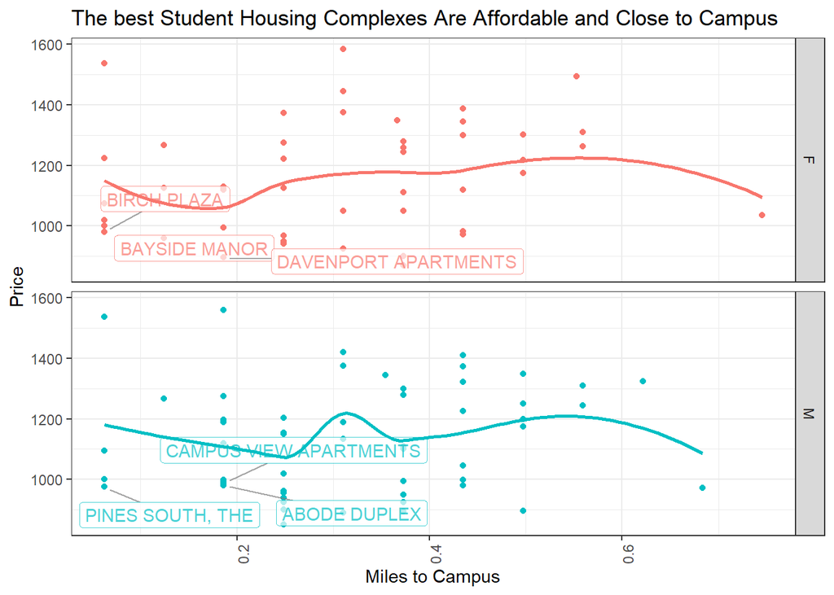

```r
### Distance ~ Price ~ Gender
CheapNClose <-
  Rent %>%
  filter(Price < quantile(Rent$Price, 0.30)) %>%
  filter(MilesToCampus < quantile(Rent$MilesToCampus, 0.30))


Rent %>%
  ggplot(aes(MilesToCampus, Price, color = Gender, group = Gender)) +
  geom_point() +
  geom_label_repel(data = CheapNClose, aes(label = Apartment),
                   box.padding   = 0.35,
                   point.padding = 0.5,
                   segment.color = 'grey50',
                   alpha = 0.7) +
  geom_smooth(se = FALSE) +
  facet_grid(Gender ~ .) +
  theme_bw() +
  theme(axis.text.x = element_text(angle = 90), legend.position = "none") +
  labs(
    title = "The best Student Housing Complexes Are Affordable and Close to Campus",
    x = "Miles to Campus",
    y = "Price",
    color = "Gender"
  )
```

### The Map

```r
### Leaflet Map
getColor <- function(Rent) {
  sapply(Rent$Price, function(Price) {
    if(Price <= 1000) {
      "green"
    } else if(Price <= 1200) {
      "yellow"
    } else {
      "red"
    } })
}

icons <- awesomeIcons(
  icon = 'ios-close',
  iconColor = 'black',
  library = 'ion',
  markerColor = getColor(Rent)
)

leaflet(options = leafletOptions()) %>%
  addTiles() %>%
  addLabelOnlyMarkers(data = CheapNClose,
             label = ~Apartment,
             labelOptions = labelOptions(noHide = T)) %>%
  addAwesomeMarkers(data = Rent,
                    lng = ~Longitude,
                    lat = ~Latitude,
                    icon = icons,
                    popup = ~paste0("Name: ", Apartment, "<br/>",
                                    "Gender: ", Gender, "<br/>",
                                    "Address: ", Address, "<br/>",
                                    "Phone: ", Phone, "<br/>",
                                    "Shared Room: ", Price, "<br/>",
                                    "Private Room: ", PrivateRoomPrice, "<br/>",
                                    "Deposit: ", Deposit, "<br/>"))
```

```
## Assuming "Longitude" and "Latitude" are longitude and latitude, respectively
```

[interactive chart not shown]